# Individual differences

In **Pilot 1**, there are 41 subjects who did the curiosity personal trait questionaire. The following analysis will only include these subjects who had personal trait scores.

# 1 Relationship between trait score and slope of curiosity-memory relationship

## 1.1 Outside

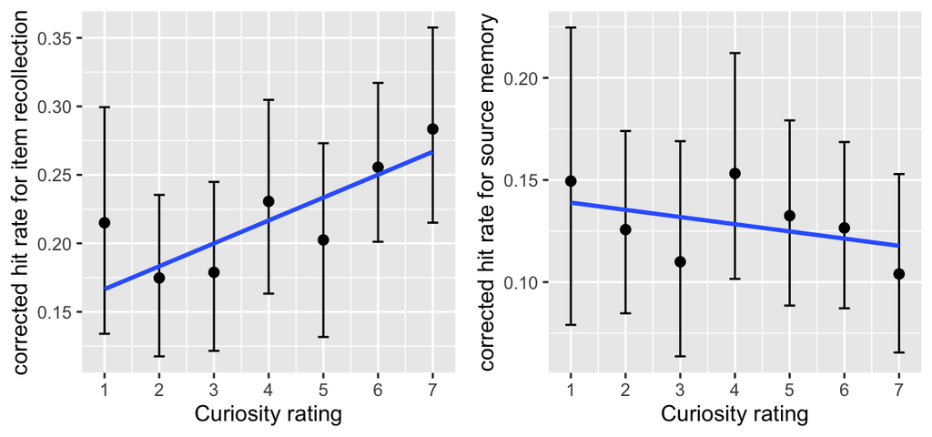

### 1.1.1 Item recollection

#### 1.1.1.1 Correlation with the average score

```
##                  Model df       AIC        BIC   logLik   Test  L.Ratio
## baseline.rating      1  3 -118.8881 -108.42132 62.44406
## rating.intercept     2  4 -122.5070 -108.55121 65.25348 1 vs 2 5.618832
## rating.slope         3  6 -124.2984 -103.36473 68.14918 2 vs 3 5.791396
## tr.intercept         4  7 -122.7253  -98.30275 68.36266 3 vs 4 0.426955
## tr.slope             5  8 -120.9114  -92.99986 68.45568 4 vs 5 0.186051
##                  p-value
## baseline.rating
## rating.intercept  0.0178
## rating.slope      0.0553
## tr.intercept      0.5135
## tr.slope          0.6662
```

#### 1.1.1.2 Correlation with the PC score

```
##                  Model df       AIC        BIC   logLik   Test  L.Ratio
## baseline.rating      1  3 -118.8881 -108.42132 62.44406
## rating.intercept     2  4 -122.5070 -108.55121 65.25348 1 vs 2 5.618832
## rating.slope         3  6 -124.2984 -103.36473 68.14918 2 vs 3 5.791396
## PC.intercept         4  7 -123.1560  -98.73348 68.57802 3 vs 4 0.857683
## PC.slope             5  8 -121.2114  -93.29987 68.60569 4 vs 5 0.055332
##                  p-value
## baseline.rating
## rating.intercept  0.0178
## rating.slope      0.0553
## PC.intercept      0.3544
## PC.slope          0.8140
```

#### 1.1.1.3 Correlation with the EC score

```
##                  Model df       AIC        BIC   logLik   Test  L.Ratio
## baseline.rating      1  3 -118.8881 -108.42132 62.44406
## rating.intercept     2  4 -122.5070 -108.55121 65.25348 1 vs 2 5.618832
## rating.slope         3  6 -124.2984 -103.36473 68.14918 2 vs 3 5.791396
## EC.intercept         4  7 -122.3607  -97.93816 68.18036 3 vs 4 0.062370
## EC.slope             5  8 -121.3980  -93.48650 68.69900 4 vs 5 1.037275
##                  p-value
## baseline.rating
## rating.intercept  0.0178
## rating.slope      0.0553
## EC.intercept      0.8028
## EC.slope          0.3085
```

### 1.1.2 Source memory

#### 1.1.2.1 Correlation with the average score

```
##                  Model df       AIC       BIC   logLik   Test   L.Ratio
## baseline.rating      1  3 -232.4874 -222.0206 119.2437
## rating.intercept     2  4 -230.9710 -217.0153 119.4855 1 vs 2 0.4835912
## rating.slope         3  6 -226.9704 -206.0368 119.4852 2 vs 3 0.0005518
## tr.intercept         4  7 -226.1594 -201.7368 120.0797 3 vs 4 1.1889441
## tr.slope             5  8 -224.5524 -196.6409 120.2762 4 vs 5 0.3929654
##                  p-value
## baseline.rating
## rating.intercept  0.4868
## rating.slope      0.9997
## tr.intercept      0.2755
## tr.slope          0.5307
```

#### 1.1.2.2 Correlation with the PC score

```
##                  Model df       AIC       BIC   logLik   Test   L.Ratio
## baseline.rating      1  3 -232.4874 -222.0206 119.2437
## rating.intercept     2  4 -230.9710 -217.0153 119.4855 1 vs 2 0.4835912
## rating.slope         3  6 -226.9704 -206.0368 119.4852 2 vs 3 0.0005518
## PC.intercept         4  7 -225.8721 -201.4496 119.9361 3 vs 4 0.9016779
## PC.slope             5  8 -224.4862 -196.5747 120.2431 4 vs 5 0.6141099
##                  p-value
## baseline.rating
## rating.intercept  0.4868
## rating.slope      0.9997
## PC.intercept      0.3423
## PC.slope          0.4332
```

#### 1.1.2.3 Correlation with the EC score

```
##                  Model df       AIC       BIC   logLik   Test   L.Ratio
## baseline.rating      1  3 -232.4874 -222.0206 119.2437
## rating.intercept     2  4 -230.9710 -217.0153 119.4855 1 vs 2 0.4835912
## rating.slope         3  6 -226.9704 -206.0368 119.4852 2 vs 3 0.0005518
## EC.intercept         4  7 -225.9834 -201.5608 119.9917 3 vs 4 1.0129408
## EC.slope             5  8 -224.0933 -196.1818 120.0466 4 vs 5 0.1099146
##                  p-value
## baseline.rating
## rating.intercept  0.4868
## rating.slope      0.9997
## EC.intercept      0.3142
## EC.slope          0.7402
```

## 1.2 Inside

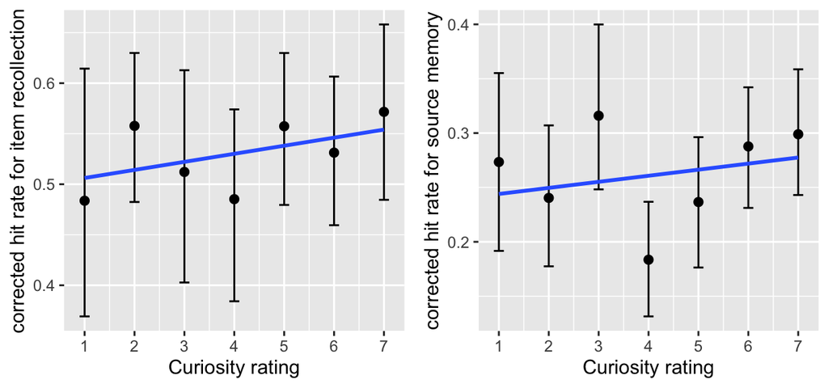

### 1.2.1 Item recollection

#### 1.2.1.1 Correlation with the average score

```
##                  Model df       AIC       BIC   logLik   Test  L.Ratio
## baseline.rating      1  3 -17.84695 -7.380140 11.92348
## rating.intercept     2  4 -16.87935 -2.923603 12.43968 1 vs 2 1.032401
## rating.slope         3  6 -13.86213  7.071498 12.93106 2 vs 3 0.982775
## tr.intercept         4  7 -11.97170 12.450869 12.98585 3 vs 4 0.109566
## tr.slope             5  8 -16.43094 11.480564 16.21547 4 vs 5 6.459243
##                  p-value
## baseline.rating
## rating.intercept  0.3096
## rating.slope      0.6118
## tr.intercept      0.7406
## tr.slope          0.0110
```

```
##                    Value  Std.Error  DF   t-value     p-value
## (Intercept)   0.04559218 0.24530516 199  0.185859 0.852744630
## CurRating     0.12135108 0.04563901 199  2.658933 0.008476866
## GN            0.15879446 0.08400857  39  1.890217 0.066176922
## CurRating:GN -0.03950462 0.01553870 199 -2.542338 0.011772483
```

#### 1.2.1.2 Correlation with the PC score

```
##                  Model df       AIC       BIC   logLik   Test  L.Ratio
## baseline.rating      1  3 -17.84695 -7.380140 11.92348
## rating.intercept     2  4 -16.87935 -2.923603 12.43968 1 vs 2 1.032401
## rating.slope         3  6 -13.86213  7.071498 12.93106 2 vs 3 0.982775
## PC.intercept         4  7 -12.70010 11.722463 13.35005 3 vs 4 0.837973
## PC.slope             5  8 -17.34293 10.568569 16.67147 4 vs 5 6.642832
##                  p-value
## baseline.rating
## rating.intercept  0.3096
## rating.slope      0.6118
## PC.intercept      0.3600
## PC.slope          0.0100
```

```
##                    Value  Std.Error  DF     t-value     p-value
## (Intercept)  -0.02143884 0.22730687 199 -0.09431671 0.924952476
## CurRating     0.11501438 0.04198712 199  2.73927785 0.006716704
## PC            0.18064172 0.07695854  39  2.34726026 0.024082270
## CurRating:PC -0.03705070 0.01413893 199 -2.62047357 0.009458334
```

#### 1.2.1.3 Correlation with the EC score

```
##                  Model df       AIC       BIC   logLik   Test  L.Ratio
## baseline.rating      1  3 -17.84695 -7.380140 11.92348
## rating.intercept     2  4 -16.87935 -2.923603 12.43968 1 vs 2 1.032401
## rating.slope         3  6 -13.86213  7.071498 12.93106 2 vs 3 0.982775
## EC.intercept         4  7 -11.95988 12.462680 12.97994 3 vs 4 0.097756
## EC.slope             5  8 -13.83390 14.077600 14.91695 4 vs 5 3.874018
##                  p-value
## baseline.rating
## rating.intercept  0.3096
## rating.slope      0.6118
## EC.intercept      0.7545
## EC.slope          0.0490
```

```
##                    Value  Std.Error  DF   t-value   p-value
## (Intercept)   0.26787870 0.22049131 199  1.214917 0.2258372
## CurRating     0.08678052 0.04128545 199  2.101964 0.0368145
## EC            0.08244413 0.07592402  39  1.085877 0.2842000
## CurRating:EC -0.02781632 0.01413116 199 -1.968438 0.0504062
```

### 1.2.2 Source memory

#### 1.2.2.1 Correlation with the average score

```
##                  Model df       AIC        BIC   logLik   Test   L.Ratio
## baseline.rating      1  3 -122.5635 -112.09672 64.28177
## rating.intercept     2  4 -121.9097 -107.95393 64.95484 1 vs 2 1.3461452
## rating.slope         3  6 -120.2308  -99.29716 66.11539 2 vs 3 2.3211109
## tr.intercept         4  7 -118.2446  -93.82202 66.12229 3 vs 4 0.0138012
## tr.slope             5  8 -117.1638  -89.25230 66.58190 4 vs 5 0.9192124
##                  p-value
## baseline.rating
## rating.intercept  0.2460
## rating.slope      0.3133
## tr.intercept      0.9065
## tr.slope          0.3377
```

#### 1.2.2.2 Correlation with the PC score

```
##                  Model df       AIC        BIC   logLik   Test   L.Ratio
## baseline.rating      1  3 -122.5635 -112.09672 64.28177
## rating.intercept     2  4 -121.9097 -107.95393 64.95484 1 vs 2 1.3461452
## rating.slope         3  6 -120.2308  -99.29716 66.11539 2 vs 3 2.3211109
## PC.intercept         4  7 -118.7426  -94.32008 66.37132 3 vs 4 0.5118555
## PC.slope             5  8 -116.7772  -88.86575 66.38863 4 vs 5 0.0346119
##                  p-value
## baseline.rating
## rating.intercept  0.2460
## rating.slope      0.3133
## PC.intercept      0.4743
## PC.slope          0.8524
```

```
##                   Value   Std.Error  DF   t-value   p-value
## (Intercept) 0.155581064 0.100706736 200 1.5448923 0.1239531
## CurRating   0.008491664 0.007354032 200 1.1546950 0.2495931
## PC          0.023095219 0.032333733  39 0.7142763 0.4793099
```

#### 1.2.2.3 Correlation with the EC score

```
##                  Model df       AIC        BIC   logLik   Test  L.Ratio
## baseline.rating      1  3 -122.5635 -112.09672 64.28177
## rating.intercept     2  4 -121.9097 -107.95393 64.95484 1 vs 2 1.346145
## rating.slope         3  6 -120.2308  -99.29716 66.11539 2 vs 3 2.321111
## EC.intercept         4  7 -119.1206  -94.69803 66.56030 3 vs 4 0.889806
## EC.slope             5  8 -119.4942  -91.58271 67.74711 4 vs 5 2.373622
##                  p-value
## baseline.rating
## rating.intercept  0.2460
## rating.slope      0.3133
## EC.intercept      0.3455
## EC.slope          0.1234
```

# 2 Relationship between trait score and curiosity ratings

## 2.1 Across all the rooms

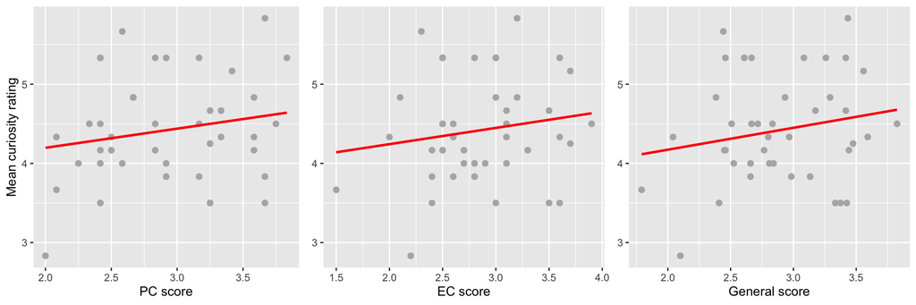

```r
cor.test(trait.ratings$meanCurRating, trait.ratings$PC, method = "pearson")
```

```
##
##  Pearson's product-moment correlation
##
## data:  trait.ratings$meanCurRating and trait.ratings$PC
## t = 1.1936, df = 39, p-value = 0.2398
## alternative hypothesis: true correlation is not equal to 0
## 95 percent confidence interval:
##  -0.1272648  0.4683367
## sample estimates:
##      cor
## 0.187736
```

```r
cor.test(trait.ratings$meanCurRating, trait.ratings$EC, method = "pearson")
```

```
##
##  Pearson's product-moment correlation
##
## data:  trait.ratings$meanCurRating and trait.ratings$EC
## t = 1.0136, df = 39, p-value = 0.317
## alternative hypothesis: true correlation is not equal to 0
## 95 percent confidence interval:
##  -0.1550854  0.4458826
## sample estimates:
##      cor
## 0.160209
```

```r
cor.test(trait.ratings$meanCurRating, trait.ratings$GN, method = "pearson")
```

```
##
##  Pearson's product-moment correlation
##
## data:  trait.ratings$meanCurRating and trait.ratings$GN
## t = 1.2316, df = 39, p-value = 0.2255
## alternative hypothesis: true correlation is not equal to 0
## 95 percent confidence interval:
##  -0.1213936  0.4729792
## sample estimates:
##       cor
## 0.1934828
```

## 2.2 Only for the *novel* rooms

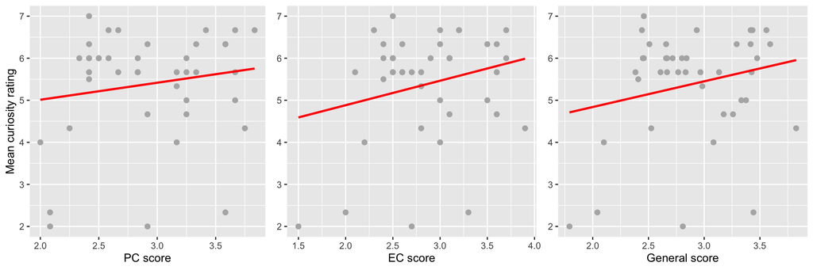

```
##
##  Pearson's product-moment correlation
##
## data:  trait.ratings.novel$meanCurRating and trait.ratings.novel$PC
## t = 1.0311, df = 39, p-value = 0.3089
## alternative hypothesis: true correlation is not equal to 0
## 95 percent confidence interval:
##  -0.1523898  0.4480918
## sample estimates:
##       cor
## 0.1628978
```

```
##
##  Pearson's product-moment correlation
##
## data:  trait.ratings.novel$meanCurRating and trait.ratings.novel$EC
## t = 1.5156, df = 39, p-value = 0.1377
## alternative hypothesis: true correlation is not equal to 0
## 95 percent confidence interval:
##  -0.0774208  0.5067301
## sample estimates:
##       cor
## 0.2358472
```

```
##
##  Pearson's product-moment correlation
##
## data:  trait.ratings.novel$meanCurRating and trait.ratings.novel$GN
## t = 1.4213, df = 39, p-value = 0.1632
## alternative hypothesis: true correlation is not equal to 0
## 95 percent confidence interval:
##  -0.09201643  0.49572239
## sample estimates:
##       cor
## 0.2219162
```

# 3 Relationship between trait score and memory performance

Here *memory performance* refers to the average corrected hit rate for “seen” response for items and average corrected hit rate for source memory.

## 3.1 Outside

### 3.1.1 Item recollection

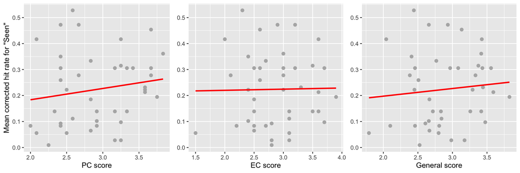

```
##
##  Pearson's product-moment correlation
##
## data:  outside.hit.rate.trait$meanSAcc and outside.hit.rate.trait$PC
## t = 1.0242, df = 39, p-value = 0.3121
## alternative hypothesis: true correlation is not equal to 0
## 95 percent confidence interval:
##  -0.1534507  0.4472232
## sample estimates:
##       cor
## 0.1618401
```

```
##
##  Pearson's product-moment correlation
##
## data:  outside.hit.rate.trait$meanSAcc and outside.hit.rate.trait$EC
## t = 0.10391, df = 39, p-value = 0.9178
## alternative hypothesis: true correlation is not equal to 0
## 95 percent confidence interval:
##  -0.2925110  0.3226357
## sample estimates:
##        cor
## 0.01663662
```

```
##
##  Pearson's product-moment correlation
##
## data:  outside.hit.rate.trait$meanSAcc and outside.hit.rate.trait$GN
## t = 0.6214, df = 39, p-value = 0.538
## alternative hypothesis: true correlation is not equal to 0
## 95 percent confidence interval:
##  -0.2151914  0.3946431
## sample estimates:
##        cor
## 0.09901413
```

### 3.1.2 Source memory

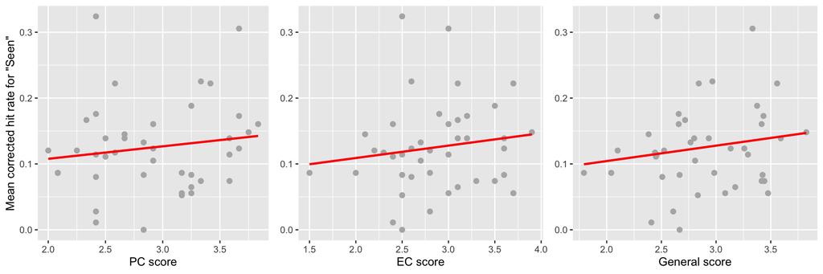

```
##
##  Pearson's product-moment correlation
##
## data:  outside.hit.rate.trait$meanSrcAcc and outside.hit.rate.trait$PC
## t = 0.91368, df = 39, p-value = 0.3665
## alternative hypothesis: true correlation is not equal to 0
## 95 percent confidence interval:
##  -0.1704777  0.4331256
## sample estimates:
##       cor
## 0.1447654
```

```
##
##  Pearson's product-moment correlation
##
## data:  outside.hit.rate.trait$meanSrcAcc and outside.hit.rate.trait$EC
## t = 0.9154, df = 39, p-value = 0.3656
## alternative hypothesis: true correlation is not equal to 0
## 95 percent confidence interval:
##  -0.1702132  0.4333469
## sample estimates:
##      cor
## 0.145032
```

```
##
##  Pearson's product-moment correlation
##
## data:  outside.hit.rate.trait$meanSrcAcc and outside.hit.rate.trait$GN
## t = 1.02, df = 39, p-value = 0.314
## alternative hypothesis: true correlation is not equal to 0
## 95 percent confidence interval:
##  -0.1541028  0.4466887
## sample estimates:
##       cor
## 0.1611896
```

## 3.2 Inside

### 3.2.1 Item recollection

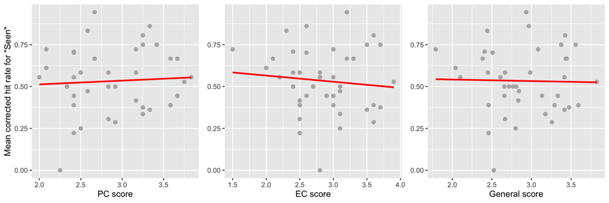

```
##
##  Pearson's product-moment correlation
##
## data:  inside.hit.rate.trait$meanSAcc and inside.hit.rate.trait$PC
## t = 0.37942, df = 39, p-value = 0.7064
## alternative hypothesis: true correlation is not equal to 0
## 95 percent confidence interval:
##  -0.2517027  0.3615488
## sample estimates:
##        cor
## 0.06064379
```

```
##
##  Pearson's product-moment correlation
##
## data:  inside.hit.rate.trait$meanSAcc and inside.hit.rate.trait$EC
## t = -0.62839, df = 39, p-value = 0.5334
## alternative hypothesis: true correlation is not equal to 0
## 95 percent confidence interval:
##  -0.3955832  0.2141287
## sample estimates:
##        cor
## -0.1001171
```

```
##
##  Pearson's product-moment correlation
##
## data:  inside.hit.rate.trait$meanSAcc and inside.hit.rate.trait$GN
## t = -0.13892, df = 39, p-value = 0.8902
## alternative hypothesis: true correlation is not equal to 0
## 95 percent confidence interval:
##  -0.3276487  0.2873767
## sample estimates:
##         cor
## -0.02224006
```

### 3.2.2 Source memory

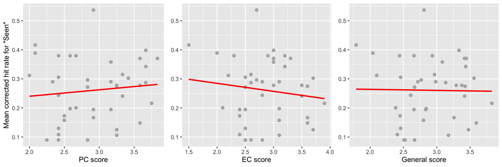

```
##
##  Pearson's product-moment correlation
##
## data:  inside.hit.rate.trait$meanSrcAcc and inside.hit.rate.trait$PC
## t = 0.68129, df = 39, p-value = 0.4997
## alternative hypothesis: true correlation is not equal to 0
## 95 percent confidence interval:
##  -0.2060762  0.4026656
## sample estimates:
##       cor
## 0.1084499
```

```
##
##  Pearson's product-moment correlation
##
## data:  inside.hit.rate.trait$meanSrcAcc and inside.hit.rate.trait$EC
## t = -0.85565, df = 39, p-value = 0.3974
## alternative hypothesis: true correlation is not equal to 0
## 95 percent confidence interval:
##  -0.4256215  0.1793965
## sample estimates:
##       cor
## -0.135746
```

```
##
##  Pearson's product-moment correlation
##
## data:  inside.hit.rate.trait$meanSrcAcc and inside.hit.rate.trait$GN
## t = -0.097525, df = 39, p-value = 0.9228
## alternative hypothesis: true correlation is not equal to 0
## 95 percent confidence interval:
##  -0.3217195  0.2934456
## sample estimates:
##         cor
## -0.01561452
```

# 4 Relationship between trait score and memory performance within *Novel* rooms

Here *memory performance* refers to the average corrected hit rate for “seen” response for items and average corrected hit rate for source memory.

## 4.1 Outside

### 4.1.1 Item recollection

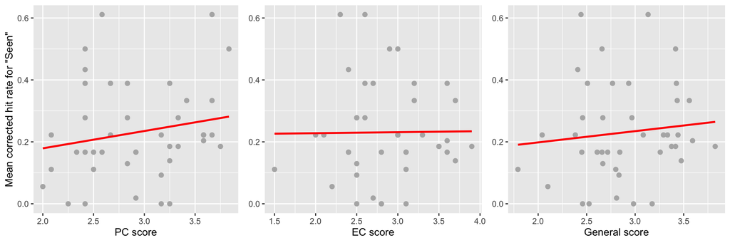

```
##
##  Pearson's product-moment correlation
##
## data:  outside.hit.rate.trait.novel$meanSAcc and outside.hit.rate.trait.novel$PC
## t = 1.1846, df = 39, p-value = 0.2434
## alternative hypothesis: true correlation is not equal to 0
## 95 percent confidence interval:
##  -0.1286693  0.4672213
## sample estimates:
##       cor
## 0.1863581
```

```
##
##  Pearson's product-moment correlation
##
## data:  outside.hit.rate.trait.novel$meanSAcc and outside.hit.rate.trait.novel$EC
## t = 0.067705, df = 39, p-value = 0.9464
## alternative hypothesis: true correlation is not equal to 0
## 95 percent confidence interval:
##  -0.2978029  0.3174325
## sample estimates:
##        cor
## 0.01084077
```

```
##
##  Pearson's product-moment correlation
##
## data:  outside.hit.rate.trait.novel$meanSAcc and outside.hit.rate.trait.novel$GN
## t = 0.68716, df = 39, p-value = 0.496
## alternative hypothesis: true correlation is not equal to 0
## 95 percent confidence interval:
##  -0.2051805  0.4034488
## sample estimates:
##      cor
## 0.109374
```

### 4.1.2 Source memory

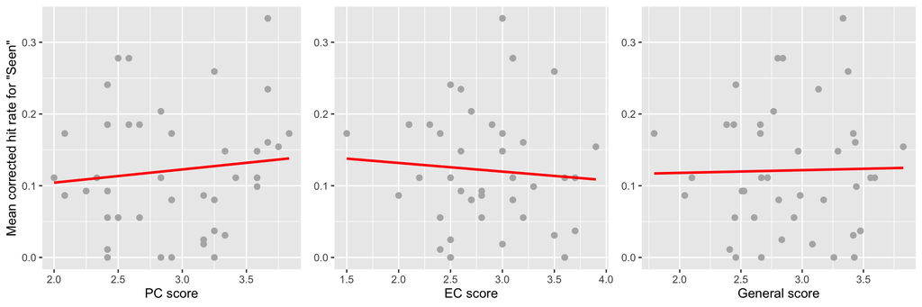

```
##
##  Pearson's product-moment correlation
##
## data:  outside.hit.rate.trait.novel$meanSrcAcc and outside.hit.rate.trait.novel$PC
## t = 0.70331, df = 39, p-value = 0.486
## alternative hypothesis: true correlation is not equal to 0
## 95 percent confidence interval:
##  -0.2027182  0.4055976
## sample estimates:
##       cor
## 0.1119118
```

```
##
##  Pearson's product-moment correlation
##
## data:  outside.hit.rate.trait.novel$meanSrcAcc and outside.hit.rate.trait.novel$EC
## t = -0.46134, df = 39, p-value = 0.6471
## alternative hypothesis: true correlation is not equal to 0
## 95 percent confidence interval:
##  -0.3728720  0.2394037
## sample estimates:
##         cor
## -0.07367294
```

```
##
##  Pearson's product-moment correlation
##
## data:  outside.hit.rate.trait.novel$meanSrcAcc and outside.hit.rate.trait.novel$GN
## t = 0.1308, df = 39, p-value = 0.8966
## alternative hypothesis: true correlation is not equal to 0
## 95 percent confidence interval:
##  -0.2885690  0.3264876
## sample estimates:
##        cor
## 0.02094056
```

## 4.2 Inside

### 4.2.1 Item recollection

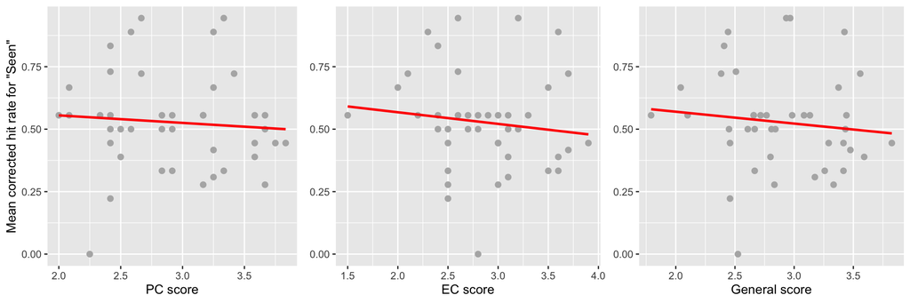

```
##
##  Pearson's product-moment correlation
##
## data:  inside.hit.rate.trait.novel$meanSAcc and inside.hit.rate.trait.novel$PC
## t = -0.49409, df = 39, p-value = 0.624
## alternative hypothesis: true correlation is not equal to 0
## 95 percent confidence interval:
##  -0.3773646  0.2344690
## sample estimates:
##         cor
## -0.07887073
```

```
##
##  Pearson's product-moment correlation
##
## data:  inside.hit.rate.trait.novel$meanSAcc and inside.hit.rate.trait.novel$EC
## t = -0.77184, df = 39, p-value = 0.4449
## alternative hypothesis: true correlation is not equal to 0
## 95 percent confidence interval:
##  -0.4146619  0.1922458
## sample estimates:
##        cor
## -0.1226593
```

```
##
##  Pearson's product-moment correlation
##
## data:  inside.hit.rate.trait.novel$meanSAcc and inside.hit.rate.trait.novel$GN
## t = -0.70496, df = 39, p-value = 0.485
## alternative hypothesis: true correlation is not equal to 0
## 95 percent confidence interval:
##  -0.4058170  0.2024664
## sample estimates:
##        cor
## -0.1121711
```

### 4.2.2 Source memory

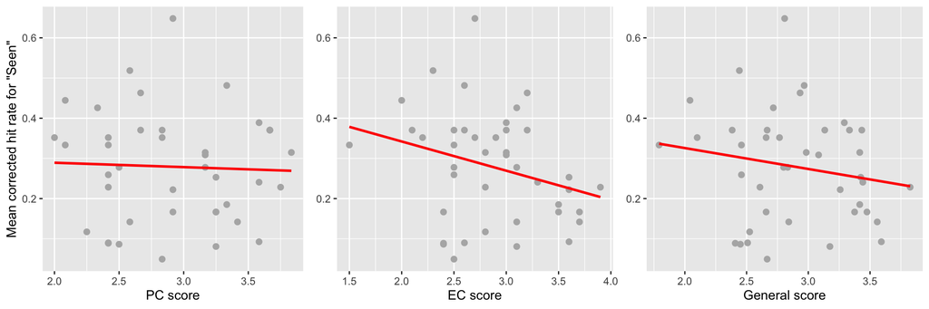

```
##
##  Pearson's product-moment correlation
##
## data:  inside.hit.rate.trait.novel$meanSrcAcc and inside.hit.rate.trait.novel$PC
## t = -0.26159, df = 39, p-value = 0.795
## alternative hypothesis: true correlation is not equal to 0
## 95 percent confidence interval:
##  -0.3450593  0.2692657
## sample estimates:
##         cor
## -0.04185168
```

```
##
##  Pearson's product-moment correlation
##
## data:  inside.hit.rate.trait.novel$meanSrcAcc and inside.hit.rate.trait.novel$EC
## t = -1.8208, df = 39, p-value = 0.07632
## alternative hypothesis: true correlation is not equal to 0
## 95 percent confidence interval:
##  -0.54096945  0.03036183
## sample estimates:
##        cor
## -0.2799031
```

```
##
##  Pearson's product-moment correlation
##
## data:  inside.hit.rate.trait.novel$meanSrcAcc and inside.hit.rate.trait.novel$GN
## t = -1.1387, df = 39, p-value = 0.2618
## alternative hypothesis: true correlation is not equal to 0
## 95 percent confidence interval:
##  -0.4615631  0.1357572
## sample estimates:
##        cor
## -0.1793855
```

# 5 Relationship between trait score and curiosity ratings between *Familiar* and *Novel* rooms

## 5.1 See whether the curiosity ratings are significantly different between *novel* and *familiar* rooms

The average curiosity rating for the *novel* rooms is 5.39 (SD = $\pm$ 1.3).

The average curiosity rating for the *familiar* rooms is 3.46 (SD = $\pm$ 1.49).

```
##
##  One Sample t-test
##
## data:  outside.hit.rate.trait.diff$diffRating
## t = 5.0341, df = 40, p-value = 1.062e-05
## alternative hypothesis: true mean is not equal to 0
## 95 percent confidence interval:
##  1.155687 2.706102
## sample estimates:
## mean of x
##  1.930894
```

## 5.2 See whether the difference in curiosity ratings are significantly correlated with trait scores

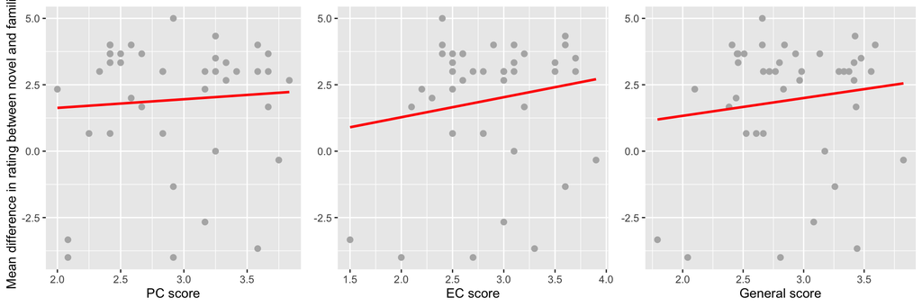

```
##
##  Pearson's product-moment correlation
##
## data:  outside.hit.rate.trait.diff$diffRating and outside.hit.rate.trait.diff$PC
## t = 0.43463, df = 39, p-value = 0.6662
## alternative hypothesis: true correlation is not equal to 0
## 95 percent confidence interval:
##  -0.2434214  0.3691931
## sample estimates:
##        cor
## 0.06942848
```

```
##
##  Pearson's product-moment correlation
##
## data:  outside.hit.rate.trait.diff$diffRating and outside.hit.rate.trait.diff$EC
## t = 1.0252, df = 39, p-value = 0.3116
## alternative hypothesis: true correlation is not equal to 0
## 95 percent confidence interval:
##  -0.1532923  0.4473530
## sample estimates:
##      cor
## 0.161998
```

```
##
##  Pearson's product-moment correlation
##
## data:  outside.hit.rate.trait.diff$diffRating and outside.hit.rate.trait.diff$GN
## t = 0.81166, df = 39, p-value = 0.4219
## alternative hypothesis: true correlation is not equal to 0
## 95 percent confidence interval:
##  -0.1861452  0.4198874
## sample estimates:
##       cor
## 0.1288863
```

### 5.2.1 Looking at the trait-rating correlation separately for the *novel* and *familiar* rooms

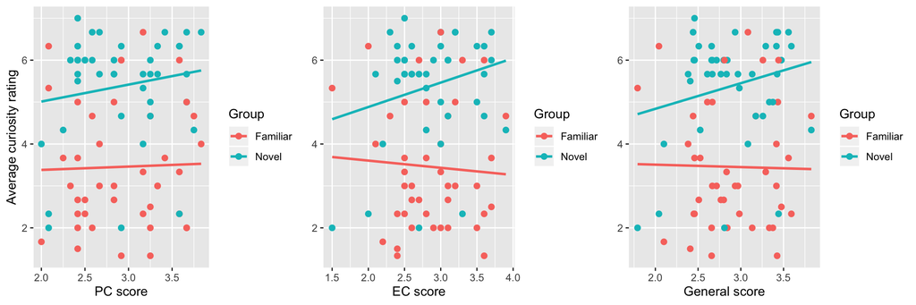

# 6 Relationship between trait score and performance differences between *Familiar* and *Novel* rooms

Here *performance difference* refers to difference in item recollection and source memory between the *novel* and *familiar* rooms (*novel* - *familiar*).

## 6.1 Outside

### 6.1.1 Item recollection

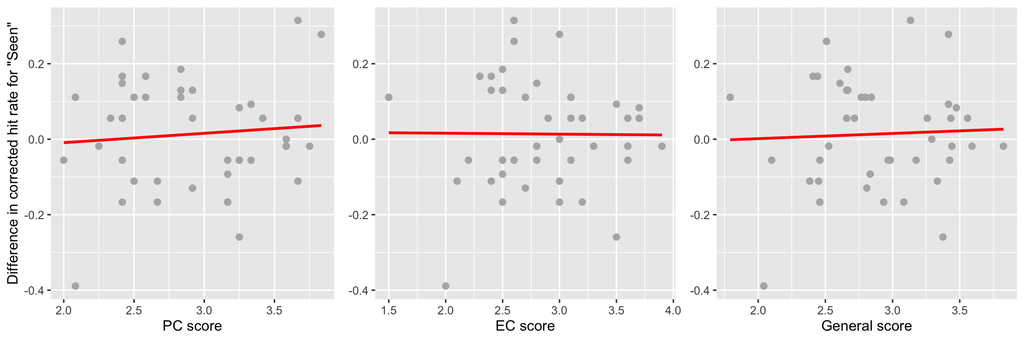

### 6.1.2 Source memory

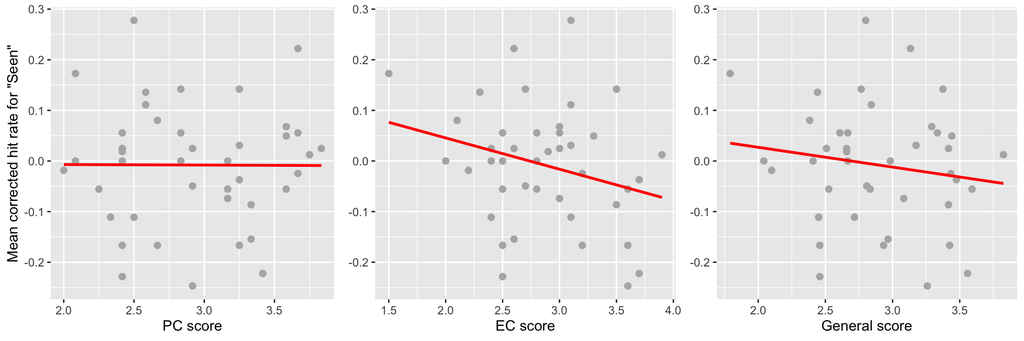

```
##
##  Pearson's product-moment correlation
##
## data:  outside.hit.rate.trait.diff$diffSrcAcc and outside.hit.rate.trait.diff$PC
## t = -0.027936, df = 39, p-value = 0.9779
## alternative hypothesis: true correlation is not equal to 0
## 95 percent confidence interval:
##  -0.3116948  0.3035950
## sample estimates:
##          cor
## -0.004473299
```

```
##
##  Pearson's product-moment correlation
##
## data:  outside.hit.rate.trait.diff$diffSrcAcc and outside.hit.rate.trait.diff$EC
## t = -1.7719, df = 39, p-value = 0.08422
## alternative hypothesis: true correlation is not equal to 0
## 95 percent confidence interval:
##  -0.53562964  0.03787149
## sample estimates:
##        cor
## -0.2729593
```

```
##
##  Pearson's product-moment correlation
##
## data:  outside.hit.rate.trait.diff$diffSrcAcc and outside.hit.rate.trait.diff$GN
## t = -0.97843, df = 39, p-value = 0.3339
## alternative hypothesis: true correlation is not equal to 0
## 95 percent confidence interval:
##  -0.4414168  0.1605071
## sample estimates:
##        cor
## -0.1547867
```

## 6.2 Inside

### 6.2.1 Item recollection

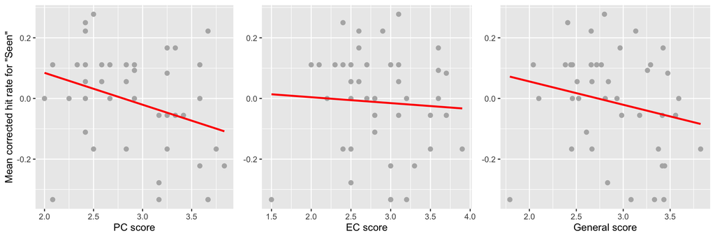

```
##
##  Pearson's product-moment correlation
##
## data:  inside.hit.rate.trait.diff$diffSAcc and inside.hit.rate.trait.diff$PC
## t = -2.1312, df = 39, p-value = 0.03943
## alternative hypothesis: true correlation is not equal to 0
## 95 percent confidence interval:
##  -0.57362473 -0.01701063
## sample estimates:
##        cor
## -0.3229709
```

```
##
##  Pearson's product-moment correlation
##
## data:  inside.hit.rate.trait.diff$diffSAcc and inside.hit.rate.trait.diff$EC
## t = -0.37592, df = 39, p-value = 0.709
## alternative hypothesis: true correlation is not equal to 0
## 95 percent confidence interval:
##  -0.3610625  0.2522265
## sample estimates:
##         cor
## -0.06008649
```

```
##
##  Pearson's product-moment correlation
##
## data:  inside.hit.rate.trait.diff$diffSAcc and inside.hit.rate.trait.diff$GN
## t = -1.3587, df = 39, p-value = 0.182
## alternative hypothesis: true correlation is not equal to 0
## 95 percent confidence interval:
##  -0.4883088  0.1017063
## sample estimates:
##        cor
## -0.2125963
```

### 6.2.2 Source memory

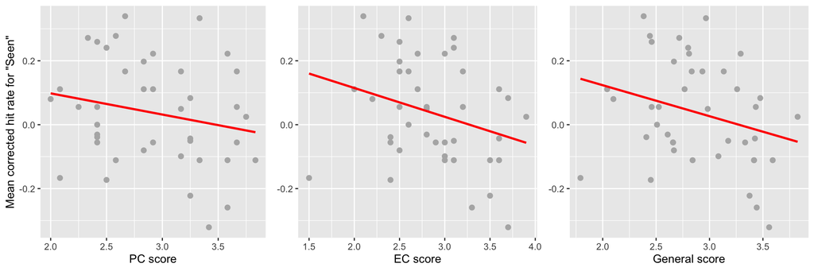

```
##
##  Pearson's product-moment correlation
##
## data:  inside.hit.rate.trait.diff$diffSrcAcc and inside.hit.rate.trait.diff$PC
## t = -1.3467, df = 39, p-value = 0.1858
## alternative hypothesis: true correlation is not equal to 0
## 95 percent confidence interval:
##  -0.4868803  0.1035606
## sample estimates:
##        cor
## -0.2108063
```

```
##
##  Pearson's product-moment correlation
##
## data:  inside.hit.rate.trait.diff$diffSrcAcc and inside.hit.rate.trait.diff$EC
## t = -1.883, df = 39, p-value = 0.06717
## alternative hypothesis: true correlation is not equal to 0
## 95 percent confidence interval:
##  -0.54769358  0.02081267
## sample estimates:
##        cor
## -0.2886862
```

```
##
##  Pearson's product-moment correlation
##
## data:  inside.hit.rate.trait.diff$diffSrcAcc and inside.hit.rate.trait.diff$GN
## t = -1.8071, df = 39, p-value = 0.07847
## alternative hypothesis: true correlation is not equal to 0
## 95 percent confidence interval:
##  -0.53947887  0.03246462
## sample estimates:
##       cor
## -0.277962
```